# Trends and Projections of Cancer in Wales

Lichita Indra

2025-12-16

## 1 Introduction

This report is a demo project following the “Cancer in Wales - trends and projections” article by Public Health Wales. The aim of this report is for the author is learn data visualisation using Tidyverse. However, the report will also provide analysis and explanation of the current and future trend of the most common type of cancers in Wales in both men and women. Explanation on the methods of projection, as used by Public Health Wales, will also be provided to help in understanding the analysis.

The original analysis can be accessed here: [Cancer in Wales Report by Public Health Wales](https://phw.nhs.wales/services-and-teams/observatory/data-and-analysis/cancer-in-wales-trends-and-projections/)

## 2 Overview of the Report

This report describes the past, current, and future trends of cancer in Wales using an aggregated data from Public Health Wales. This report will provide description and explanation of:

- Projections of cancer incidence up to 2035, both overall (excluding Non-Melanoma Skin Cancer) and for three of the four most common types of cancer in Wales.
- Information on cancer screening and how we can reduce the risk of getting cancer.
- Explanation on the data and projection methods used.

## 3 Key Points on Cancer Trends in Wales

- Public Health Wales estimated that around 1 in 4 deaths in Wales in 2024 are caused by cancer, with lung cancer caused the most deaths. This is followed by bowel, cancer of unknown origin, prostate, and breast cancer.
- Cancer in Wales is projected to be increasing overtime. This is because the population are getting old and cancer is more common in older people.
- Screening and reducing behavioural risk factors to cancer such as smoking, alcohol consumption, physical inactivity, and obesity, among others, can help to reduce the impact and risk of getting cancer.

## 4 Trends and Projections for All Cancers (1990 - 2035)

Cancer in Wales has been increasing in the last three decades and is expected to continue up to 2035. This means more people in Wales are being and will be diagnosed with cancer.

More than half of all new cancer cases in Wales (excluding non-melanoma skin cancer) are prostate, breast, lung, and colorectal (bowel) cancers. These cancer types had between 2,500-3,100 new cases per year, especially in 2019. According to Public health Wales, in 2024, lung cancer was the leading cause of cancer death in Wales, followed by bowel, prostate, and breast cancers.

Cancer can lead to death if it was diagnosed at a later stage, where the cancer has grown too big and difficult to cure. However, if cancer is found and treated early, people are more likely to survive. The most effective ways to find cancer early is to attend screening when you are invited to one. The later part of this report will provide more explanation about cancer screening programmes in Wales and information about how risks of getting cancer can be reduced.

### 4.1 Trends and Projections of All Cancers in Women

In 2019, there were around 9,800 cancer cases among women living in Wales. It is projected that there will be around 11,000 (range of estimation: 10,500-12,500) new cancer cases in 2035. This represents 12.25% increase within 15 years from 2020 to 2035.

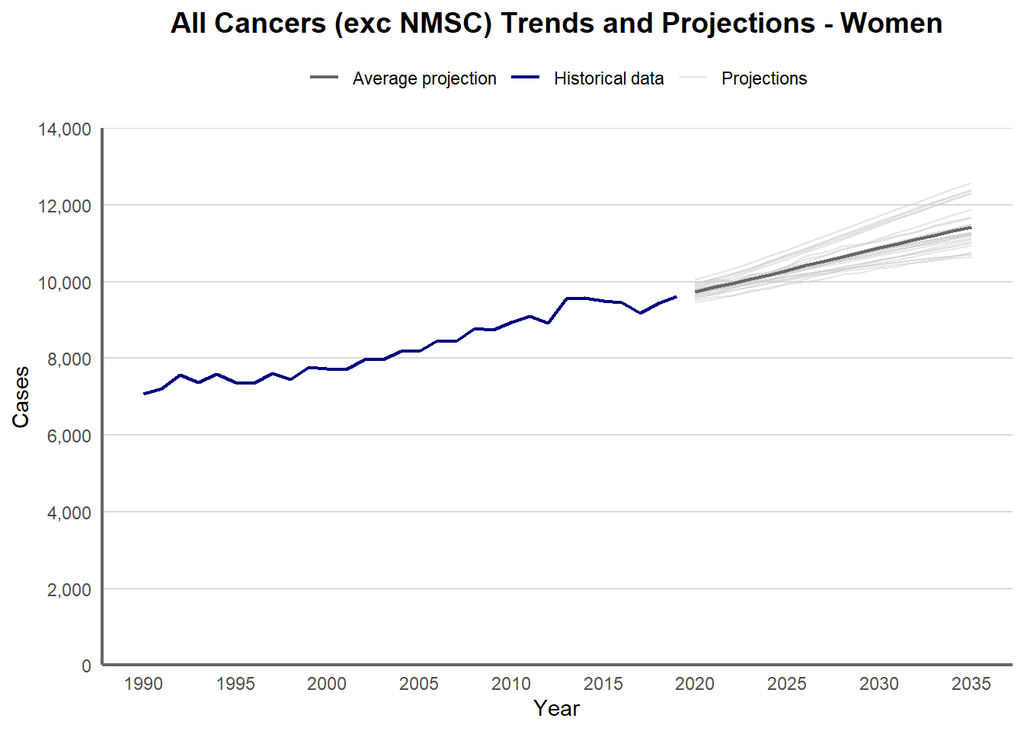

### 4.2 Trends and Projections of All Cancers in Men

Cancer cases among men living in Wales tends to be higher compared to women. In 2019, there were around 11,000 cancer cases per year, which slightly decreased from 2019. However, the annual cancer cases for men in Wales is estimated to increase to around 13,000 (range of estimation: 11,800 - 14,000) in 2035 or about 18.2% increase.

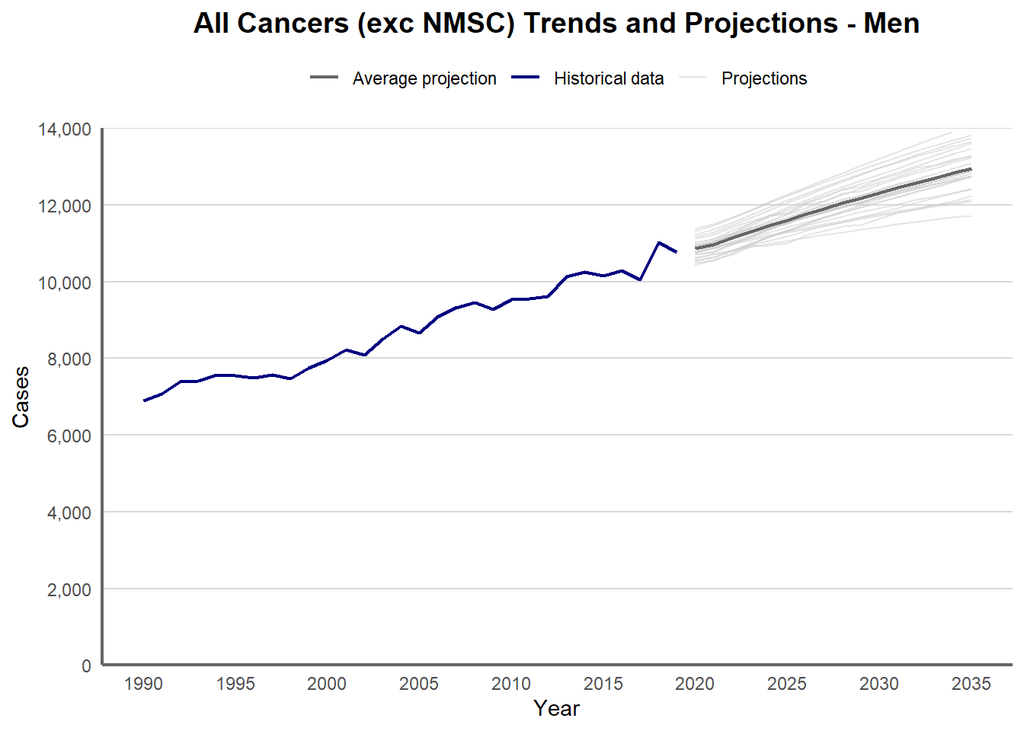

Public Health Wales estimated that between 2017 and 2019, there were around 20,031 new cancer cases per year. This is 3,511 more cases per year compared to 2002 to 2004, or around 21% increase over 15 years. If this trend continues, there could be 24,371 cancer cases per year by 2035 (around 11% increase on average from 2025 to 2035) for both women and men living in Wales.

## 5 The Impact of Age on Cancer Trends and Projections

Age is known as one of the most significant risk factor for cancer. This means, when people grow older, their risk of getting cancer is higher than when they were younger. There are many reasons why this is the case, but it is mostly because as we grow older, some risk factors for cancer such as smoking, alcohol consumption, unhealthy diets, or exposure to chemicals or air pollution build up and start to take a toll on our bodies. Hence, the likelihood of being diagnosed with cancer goes up as we get older, as shown below.

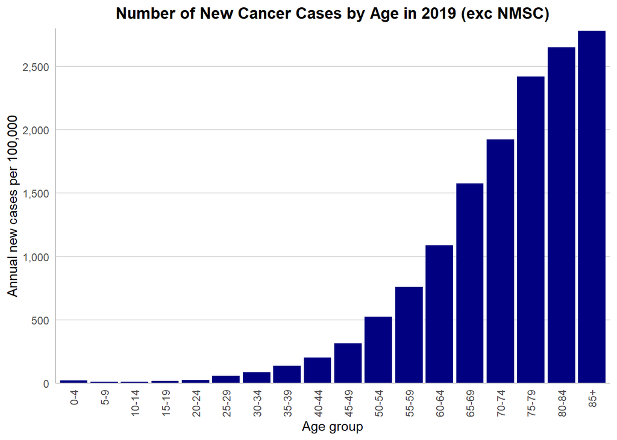

As the number of older people in Wales will go up over time, it is expected that the number of new cancer cases will also go up. In 20 years period from 2005 to 2025, the number of people aged 65 and above is estimated to have increased by 186,000 people (+36%) as seen below. It is expected that in 10 years from 2025 to 2035, there will be 135,000 more people (+19%) who are above 65 years old.

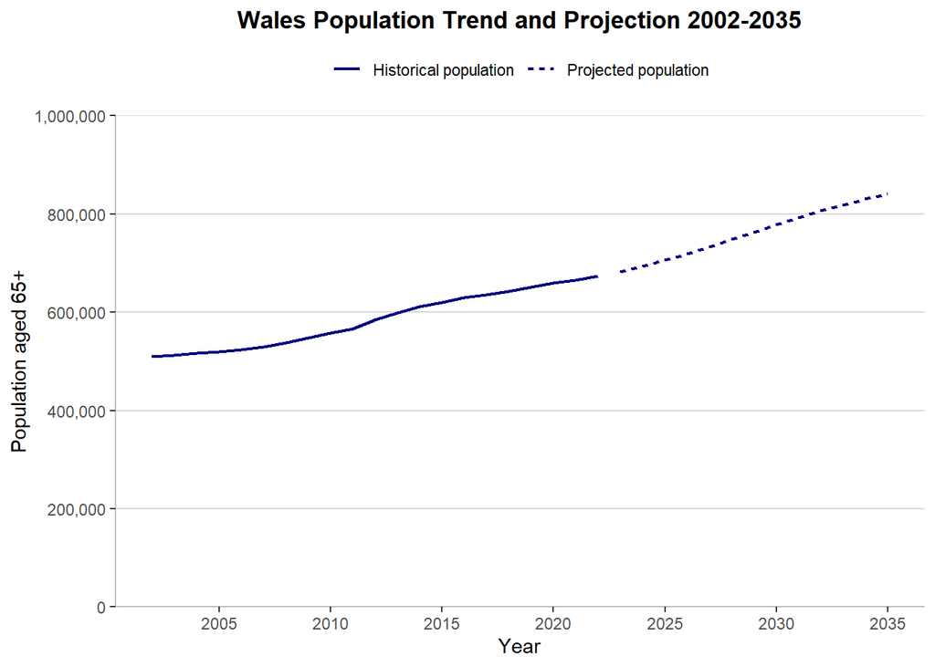

## 6 Trends of Lung Cancer (1990-2019)

In 2024, lung cancer caused 1,759 deaths or nearly 5 deaths per day in Wales. This is mostly because people were diagnosed late and it was already difficult to treat the cancer. Public Health Wales estimated that people who got diagnosed at an early stage have 55% chance of surviving lung cancer and live for 5 more years or longer. This chance can go down to 3% if people are diagnosed at a later stage. Therefore, finding cancer early is important and screening might help to find more lung cancers at an early stage.

### 6.1 Lung Cancer in Women

There were increasingly more women diagnosed with lung cancer in Wales. Between 2017-2019, there were on average 1,204 women diagnosed with lung cancer each year. This is 325 (37%) more people on average compared to 2002-2004.

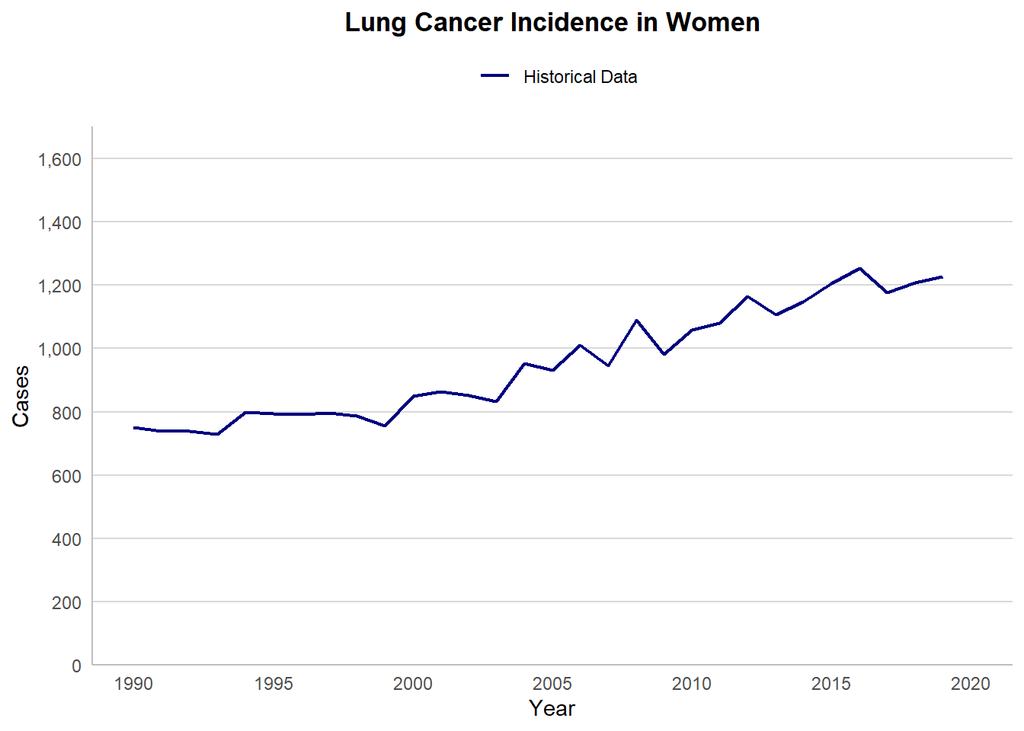

### 6.2 Lung Cancer in Men

On the other hand, there were less men diagnosed with lung cancer in Wales compared to 30-40 years ago. However, there is still more men than women who are diagnosed with lung cancer. In 2017-2019, there were on average 1,324 men in Wales diagnosed with lung cancer each year. This is 36 (3%) more people per year compared to 2002-2004.

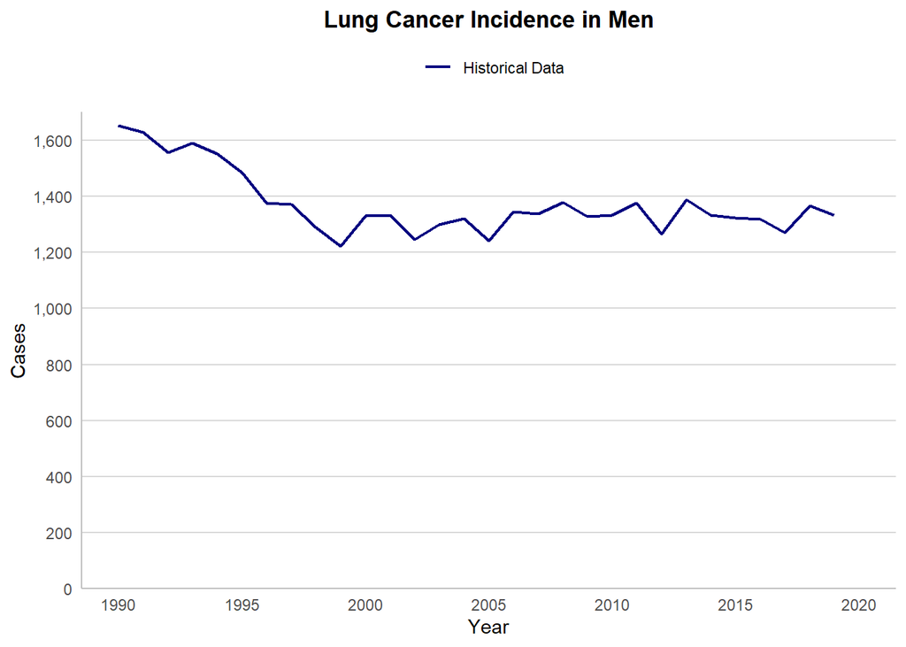

Projections on lung cancer cases were not provided due to uncertainties in predicting the impacts of smoking and lung screening. Therefore, it is hard to estimate the number of lung cancer cases in the future.

## 7 Trends and Projections of Colorectal Cancer (1990-2035)

In 2024, colorectal (bowel) cancer caused 987 deaths in Wales. Although the number of deaths is lower than lung cancer, bowel cancer is more common. There were on average 2,396 people diagnosed with bowel cancer each year between 2017-2019. This is 429 (22%) more cases compared to 2002-2004. If this trend continues, Public Health Wales estimated that there could be 2,832 bowel cancer cases per year by 2035 or 9% increase from 2025-2035. This is mostly due to having more older people in Wales over time.

### 7.1 Colorectal Cancer in Women

Then number of bowel cancer cases has gone up and down over the past three decades. However, it seems to be increasing in 2017-2019 and is projected to continue to slightly increase over time. In 2019, there were around 1,100 new bowel cancer cases per year among women in Wales. It is projected that this number will be around the same, accounting for the average number of all projections. However, this projection ranges between 1,000-1,400 new cases per year by 2035, representing up to 27% increase.

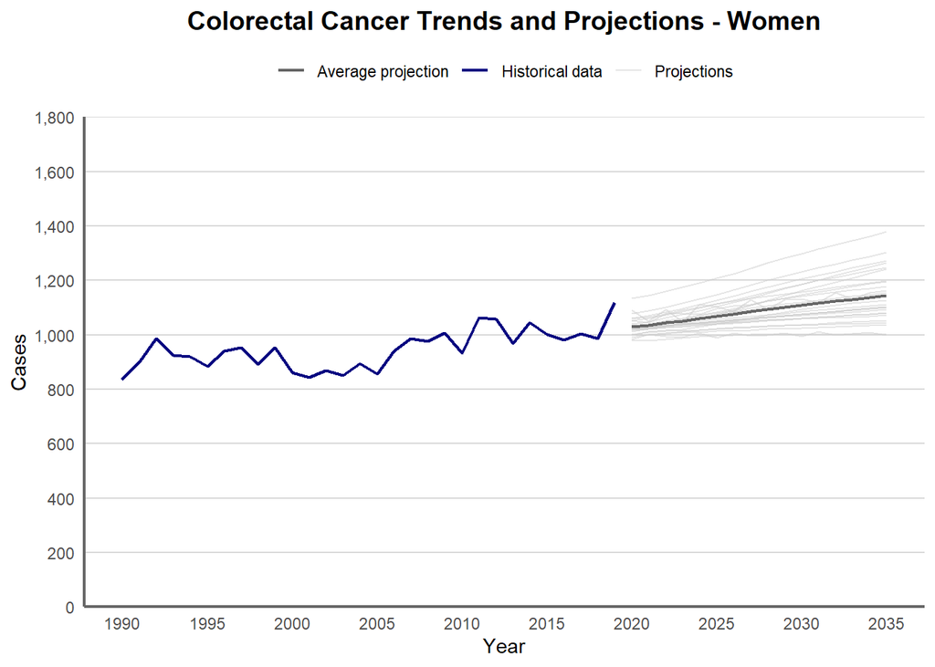

### 7.2 Colorectal Cancer in Men

Similar to lung cancer, the number of bowel cancer in men living in Wales is historically higher than women and is projected to stay higher. The increase is also more apparent in both past and future trends. In 2019, there were a bit more than 1,400 new bowel cancer cases among men in Wales. This number is projected to be slightly less than 1,700 (range of estimation: 1,400-1,800+) in 2035 or about 21% increase.

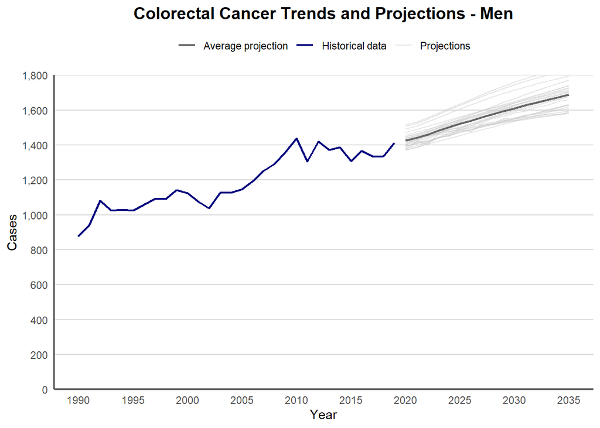

## 8 Trends and Projections of Prostate Cancer in Men (1990-2035)

Prostate cancer is the most common type of cancer among men living in Wales and it caused 624 deaths in 2024. Between 2017-2019, there were on average 3,043 men diagnosed with prostate cancer each year. This is 931 (44%) more people on average compared to 2002-2004. If this trend continues, there could be 4,244 prostate cancer cases each year by 2035. This is a projected increase of 18% from 2025-2035.

Prostate cancer is much more common in older men. As the population gets older, it is expected that prostate cancer cases will also go up. Additionally, more awareness and testing for prostate cancer could also mean more cases are detected, leading to increased number of cases every year. However, this may also include cases that might not have caused harm within a person’s lifetime.

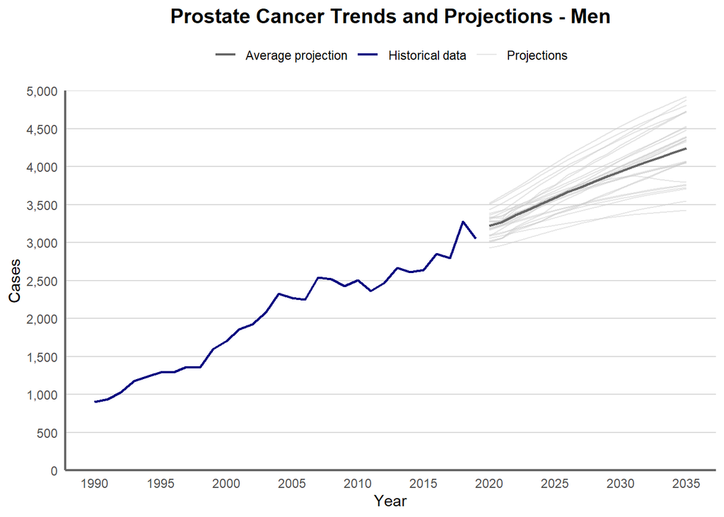

## 9 Trends and Projections of Breast Cancer in Women (1990-2035)

Men can get breast cancer although it is very rare compared to women. Therefore, this report focuses on breast cancer in women.

Breast cancer is the most common type of cancer among women living in Wales and it caused 589 deaths in 2024. Between 2017-2019, there were on average 2,793 women diagnosed with breast cancer each year. This is 384 (16%) more people on average compared to 2002-2004. If this trend continues, there could be 3,449 breast cancer cases among women each year by 2035. This is a projected increase of 11% from 2025-2035.

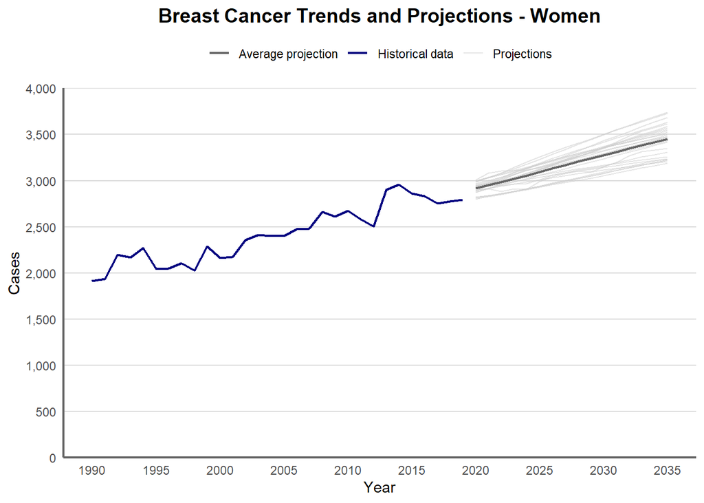

## 10 Cancer Screening Programme in Wales

Screening programmes for bowel, breast, and cervical cancers are available in Wales. Screening can find cancer early, when treatment is more likely to work. Some screening programmes can also stop cancer before it starts by finding and treating early changes, such as in bowel screening.

### 10.1 Bowel Screening Wales

Screening for bowel cancer is available to people aged 50-74 years who are living in Wales. They will be invited to take part in bowel screening every 2 years via postal services. Test kit will be delivered along with the invitation and instructions, so that people can complete the screening at home. Test results will be available within two weeks after sending the kit back. People who are not within 50-74 years of age can consult their GP or request for a kit if they have any concerns. More information can be found here: [Bowel Screening Wales](https://phw.nhs.wales/services-and-teams/screening/bowel-screening/).

### 10.2 Breast Test Wales

Screening for breast cancer is available to women aged 50-70 who are living in Wales. They will be invited to take x-rays of the breast (mammograms) every 3 years as part of the screening. Women aged 70 and above will not be invited for screening but can ask for an appointment. More information can be found here: [Breast Test Wales](https://phw.nhs.wales/services-and-teams/screening/breast-screening/).

### 10.3 Cervical Screening Wales

Cervical screening is available for women and people with a cervix aged 25-64 who are living in Wales. This screening can prevent cervical cancer from developing or pick it up at an early stage. The screening (smear test) will look for high-risk types of Human Papillomavirus (HPV) that can cause cell changes on the cervix. Finding cell changes can prevent cervical cancer from developing. More information can be found here: [Cervical Screening Wales](https://phw.nhs.wales/services-and-teams/screening/cervical-screening-wales/).

### 10.4 Screening for Prostate Cancer is Not Recommended

Screening for prostate cancer is not recommended in the UK due to low accuracy that might falsely diagnose men who do not have prostate cancer and/or miss those who do have cancer. This means some men might have to undergo unnecessary and unpleasant tests and treatment. Therefore, a nation-wide screening programme for prostate cancer is not recommended. Those who have concerns about their health should contact their GP instead.

### 10.5 Screening for Lung Cancer is Currently Developed

Screening for lung cancer is currently (as of June 2025) being developed in Wales, specifically targeting people aged 55 to 74 who are either current or previous smokers. The implementation of lung screening in Wales might be integrated with smoking cessation service. Public Health Wales will be leading the lung screening programme and might start inviting people in 2027.

## 11 Reducing Cancer Risks

In 2015, about 4 in 10 new cancer cases in Wales were linked to risk factors that can be changed. A study found that around 60% of new cancer cases, which includes lung, bowel, breast, and melanoma skin cancer are potentially preventable by reducing risk factors for cancer. Some of the most important risk factors for cancer include:

- Smoking tobacco
- Alcohol consumption
- Overweight or obesity
- Eating too little fibre or too much processed meat
- Exposure to ultraviolet (UV) radiation from the sun or sunbeds
- Exposure to harmful chemicals such as asbestos
- Certain infections, such as HPV

Different cancer types have different risk factors. For example, smoking tobacco is the biggest risk factor for lung cancer, while UV radiation is the biggest risk for skin cancer. Some risk factors may apply to many different types of cancer For example, alcohol consumption and overweight / obesity are well-known risk factors for breast, cervical, liver, and oesophageal (throat) cancers.

## 12 Understanding Projections

This report was prepared using publicly available data and projections from Public Health Wales which can be accessed from the original report mentioned on the introduction section of this report.

Projections help us estimate and understand what might happen in the future if past trends continue. However, they are not 100% accurate as there are many uncertainties that might affect our projections. For example, new policies or changes in behaviour. To make these projections more robust (more accurate), Public Health Wales used different methods and approaches, including:

- Using different projection methods such as Autoregressive Integrated Moving Average (ARIMA), Prophet, and Carry-forward age-specific rate.
- Some methods were made to predict the number of cases directly while others were used to predict cancer rates and then multiplied by the future population estimates.
- Some methods were used to look at the whole population while some looked at different age groups separately.
- Projections were made using different end years for the data to avoid potential problems caused by delays in cancer case registrations.

To get the main projection, projection results from the different methods and approaches were taken together and calculated for the average. This makes the projection more robust or potentially more accurate. Using different methods and approaches also show us how much the results depend on the choices and assumptions made. Projections were made using cancer data up until 2019. This is because cancer data from 2020 and 2021 were affected by the COVID-19 pandemic, which makes them less helpful for predicting long-term trends.

For more information, look at the “Understanding Projections” section on [the original report by Public Health Wales](https://phw.nhs.wales/services-and-teams/observatory/data-and-analysis/cancer-in-wales-trends-and-projections/).